# R Notebook

```r
suppressPackageStartupMessages(library(tidyverse))
library(gapminder)
```

# Factor Basics

## Resources

http://stat545.com/block029_factors.html

## Activities/Points

- What is a factor? A truly categorical variable. You can think of it as a vector that:
  - has character entries on the surface
  - are integers underneath
  - has **levels**

Examples of Base R’s obsession with coercing to factors:

```r
data.frame(x=c("A", "B")) %>%
  str()
```

```
## 'data.frame':    2 obs. of  1 variable:
##  $ x: Factor w/ 2 levels "A","B": 1 2
```

```r
lotr1 <- "https://raw.githubusercontent.com/jennybc/lotr-tidy/master/data/The_Fellowship_Of_The_Ring.csv" %>%
  read.csv()
lotr2 <- "https://raw.githubusercontent.com/jennybc/lotr-tidy/master/data/The_Return_Of_The_King.csv" %>%
  read.csv()
str(lotr1)
```

```
## 'data.frame':    3 obs. of  4 variables:
##  $ Film  : Factor w/ 1 level "The Fellowship Of The Ring": 1 1 1
##  $ Race  : Factor w/ 3 levels "Elf","Hobbit",..: 1 2 3
##  $ Female: int  1229 14 0
##  $ Male  : int  971 3644 1995
```

```r
str(lotr2)
```

```
## 'data.frame':    3 obs. of  4 variables:
##  $ Film  : Factor w/ 1 level "The Return Of The King": 1 1 1
##  $ Race  : Factor w/ 3 levels "Elf","Hobbit",..: 1 2 3
##  $ Female: int  183 2 268
##  $ Male  : int  510 2673 2459
```

Examples of problems encountered with factors. (ideas came from [R Bloggers](https://www.r-bloggers.com/factors-are-not-first-class-citizens-in-r/))

```r
iris %>%
  mutate(Species = ifelse(Species == "versicolor", "vers", Species))
```

| Sepal.Length | Sepal.Width | Petal.Length | Petal.Width | Species |
| --- | --- | --- | --- | --- |
| 5.1 | 3.5 | 1.4 | 0.2 | 1 |
| 4.9 | 3.0 | 1.4 | 0.2 | 1 |
| 4.7 | 3.2 | 1.3 | 0.2 | 1 |
| 4.6 | 3.1 | 1.5 | 0.2 | 1 |
| 5.0 | 3.6 | 1.4 | 0.2 | 1 |
| 5.4 | 3.9 | 1.7 | 0.4 | 1 |
| 4.6 | 3.4 | 1.4 | 0.3 | 1 |
| 5.0 | 3.4 | 1.5 | 0.2 | 1 |
| 4.4 | 2.9 | 1.4 | 0.2 | 1 |
| 4.9 | 3.1 | 1.5 | 0.1 | 1 |

[output cut: 140 more lines]

```r
c(iris$Species, "setosa")
```

```
##   [1] "1"      "1"      "1"      "1"      "1"      "1"      "1"
##   [8] "1"      "1"      "1"      "1"      "1"      "1"      "1"
##  [15] "1"      "1"      "1"      "1"      "1"      "1"      "1"
##  [22] "1"      "1"      "1"      "1"      "1"      "1"      "1"
##  [29] "1"      "1"      "1"      "1"      "1"      "1"      "1"
##  [36] "1"      "1"      "1"      "1"      "1"      "1"      "1"
##  [43] "1"      "1"      "1"      "1"      "1"      "1"      "1"
##  [50] "1"      "2"      "2"      "2"      "2"      "2"      "2"
##  [57] "2"      "2"      "2"      "2"      "2"      "2"      "2"
##  [64] "2"      "2"      "2"      "2"      "2"      "2"      "2"
##  [71] "2"      "2"      "2"      "2"      "2"      "2"      "2"
##  [78] "2"      "2"      "2"      "2"      "2"      "2"      "2"
##  [85] "2"      "2"      "2"      "2"      "2"      "2"      "2"
##  [92] "2"      "2"      "2"      "2"      "2"      "2"      "2"
##  [99] "2"      "2"      "3"      "3"      "3"      "3"      "3"
## [106] "3"      "3"      "3"      "3"      "3"      "3"      "3"
## [113] "3"      "3"      "3"      "3"      "3"      "3"      "3"
## [120] "3"      "3"      "3"      "3"      "3"      "3"      "3"
## [127] "3"      "3"      "3"      "3"      "3"      "3"      "3"
## [134] "3"      "3"      "3"      "3"      "3"      "3"      "3"
## [141] "3"      "3"      "3"      "3"      "3"      "3"      "3"
## [148] "3"      "3"      "3"      "setosa"
```

- Base R way of interacting with factors.
  - `factor()`, or `forcats::parse_factor()`.
  - `levels()`
  - `nlevels()`
  - `forcats::fct_count()`

Here is a sample of 10 letters drawn from the possibilities “a”, “b”, and “c”:

```r
set.seed(10)
(draw <- sample(letters[1:3], size = 10, replace = TRUE))
```

```
##  [1] "b" "a" "b" "c" "a" "a" "a" "a" "b" "b"
```

Convert `draw` to a factor. What are the levels? How many are there? How many of each category was drawn?

## Concatenating Factors

We saw that `c()` doesn’t work for concatenating. Modify the following code to use `fct_c()` from the `forcats` package:

```r
c(lotr1$Film, lotr2$Film)
```

```
## [1] 1 1 1 1 1 1
```

Try binding by row `lotr1` and `lotr2`:

- with `rbind()`
- with `bind_rows()`

Which one is more lenient? Which would you prefer?

## Levels don’t always have to be present

Example of what this means:

```r
gap_gs <- gapminder %>% filter(country %in% c("Germany", "Sweden"))
nlevels(gap_gs$country)
```

```
## [1] 142
```

Sometimes this is good. Other times, not.

1. **When it’s good**:

Here’s the gapminder data down to rows where population is less than a quarter of a million, i.e. 250,000:

```r
gap_small <- gapminder %>%
  filter(pop < 250000)
```

Exercise: Make a bar chart of the number of times a continent has a country with population < 250,000 in the `gapminder` data set. Try with and without `scale_x_discrete(drop=FALSE)`.

2. **When it’s bad**: Usually not harmful. Can be, if you ever use the `levels()` function.

How to fix by dropping levels:

- Base R: `droplevels()` operates on either an entire data frame or a factor.
- `forcats::fct_drop()` only operates on a factor.

Exercise: get rid of the unused factor levels for country and continent in different ways:

- `droplevels()`
- `fct_drop()` inside `mutate()`
- Re-defining the variable as a factor

## Ordering

Ordering of levels is alphabetical, by default. Usually not useful!

```r
cont <- gapminder$continent
levels(cont)
```

```
## [1] "Africa"   "Americas" "Asia"     "Europe"   "Oceania"
```

### Ordering with no other info

Plotting happens in the order of the factor levels:

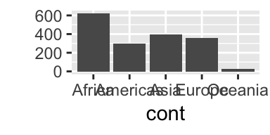

```r
qplot(cont)
```

Much more effective to always consider a meaningful order when plotting a categorical variable.

Reorder by frequency:

- Rearrange by frequency: `fct_infreq()`.
- Reverse: `fct_rev()`

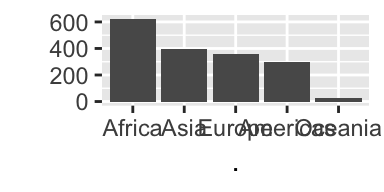

```r
cont %>%
  fct_infreq() %>%
  qplot()
```

Could also arrange by the order they appear in the factor with `fct_inorder()`.

### Ordering by Another Variable

Here are the 2007 life expectancies of Asian countries:

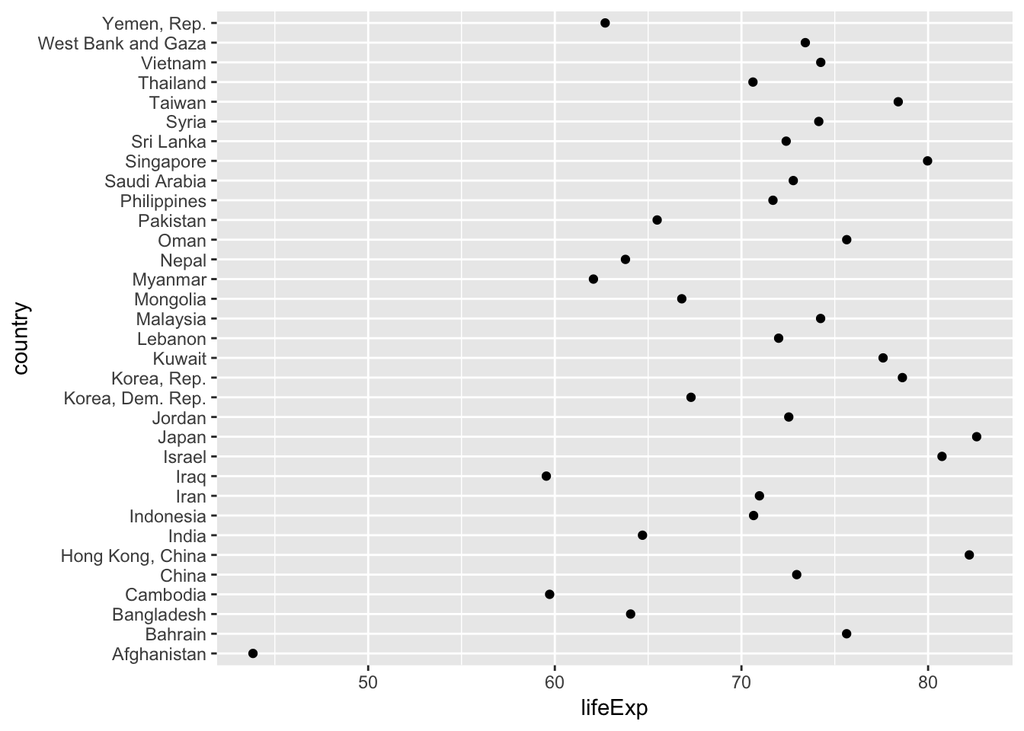

```r
gap_asia_2007 <- gapminder %>%
  filter(year == 2007, continent == "Asia")
ggplot(gap_asia_2007, aes(lifeExp, country)) + geom_point()
```

What about when life Expectancy is not unique? Example: life expectancy of each continent:

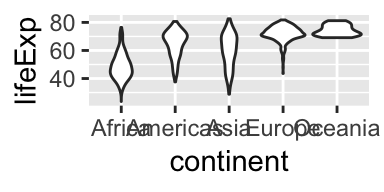

```r
ggplot(gapminder, aes(continent, lifeExp)) +
  geom_violin()
```

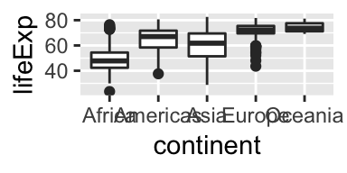

```r
ggplot(gapminder, aes(continent, lifeExp)) +
  geom_boxplot()
```

`fct_reorder(f, x)` still works, but does some internal wrangling: a summary statistic (default: median) is computed on `x` for each category in the factor `f`.

Exercise: Try making the above box plot and violin plots, ordered by median lifeExp. Try other functions to order by by modifying the `.fun` argument.

What if we have two variables plus a non-positional categorical variable? Example: Life expectancy for some select countries. Want legend “ordered by life expectancy” – but what does that mean?

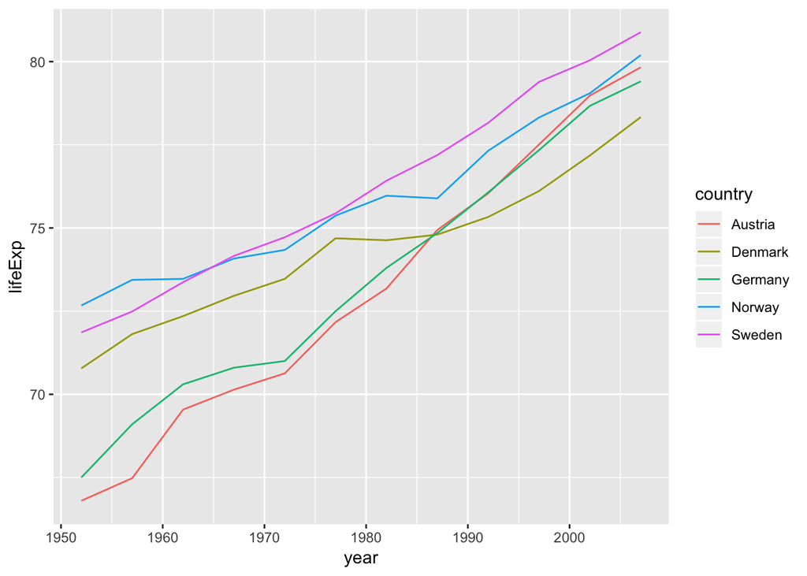

```r
select_countries <- c("Sweden", "Denmark", "Norway", "Germany", "Austria")
gap_select <- gapminder %>%
  filter(country %in% select_countries) %>%
  droplevels()
ggplot(gap_select, aes(year, lifeExp)) +
  geom_line(aes(group=country, colour=country))
```

Use `fct_reorder2(f, x, y)` to reorder factor `f`:

- `.fun` is a function of `x` and `y`. Should return a single value, and is applied to each category.
- Default is `.fun = last2`, which looks at x-y plot for each category; uses the y-value furthest to the right.

Exercise: Reorder the above line graph so that the legend is in order of last life expectancy. Useful for black-and-white printing!

### Ordering “because I said so”

Remember the plot of Asian life expectancies in 2007? What if you’re preparing a report for the Syrian government? You’d want to put Syria first (for reasons external to the data).

Here’s how to use `fct_relevel()` to do that. Exercise: modify the code so that:

- in addition, Sweden goes second.
- instead of first, Syria goes after the third level. Hint: use `after=`.

```r
gap_asia_2007$country %>%
  fct_relevel("Syria") %>%
  levels() %>%
  head()
```

```
## [1] "Syria"       "Afghanistan" "Albania"     "Algeria"     "Angola"
## [6] "Argentina"
```

## Re-coding a Factor

Want “United States” to read “USA” instead? Just use `fct_recode()`. (Sadly, no metaprogramming happens here).

Exercise: modify the following code to also change “Canada” to read “Can”. Hint: use a comma.

```r
gap_big_north <- gapminder %>%
  filter(country %in% c("Canada", "United States", "Mexico")) %>%
  droplevels()
gap_big_north$country %>%
  fct_recode("USA" = "United States") %>%
  levels()
```

```
## [1] "Canada" "Mexico" "USA"
```

## Condensing a Factor

We can specify levels to combine. Let’s look at the world in 2007:

```r
gap_2007 <- gapminder %>%
  filter(year == 2007)
```

We can arbitrarily combine levels using `fct_collapse()`. For example, combine Europe and Asia into one factor called “combo”:

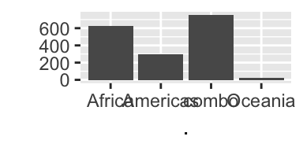

```r
cont %>%
  fct_collapse("combo" = c("Europe", "Asia")) %>%
  qplot()
```

More practically, we can lump the least frequent levels together as “Other”. Modify the above code to use `fct_lump()` instead of `fct_collapse()` so that:

- The bar chart shows the two most frequently observed continents,
- The bar chart shows the two least frequently observed continents (Hint: use negative `n`).
- You let `fct_lump()` decide on the number of non-other continents. How is this chosen?
- Note: you can manually specify non-other levels using `fct_other()`.

We can use the `w` argument to lump by another variable.

Exercise: Modify the following violin plot of life expectancies of African countries, so that:

1. There are 4 “violins” corresponding to countries with the highest lifeExp.
2. There are 4 “violins” corresponding to countries with the highest gdpPercap

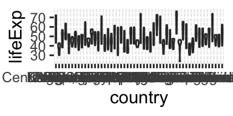

```r
gap_africa <- gapminder %>%
    filter(continent == "Africa")
gap_africa %>%
    mutate(country = fct_lump(country)) %>%
    ggplot(aes(country, lifeExp)) +
    geom_violin()
```